# Model Validation

Credit Risk Intelligence Platform

Nihira Sharma

2026-06-29

```r
knitr::opts_chunk$set(echo=TRUE, message=TRUE, warning=FALSE,
                      fig.width=10, fig.height=6, results='markup')
library(tidyverse)
library(scales)
library(ROCR)
library(knitr)
source("../R/model_utils.R")
```

```
## Metric functions loaded
##   - compute_gini()
##   - compute_ks()
##   - compute_auc()
##   - compute_calibration()
##   - compute_lift()
##   - compute_confusion_matrix()
##   - summarise_metrics()
```

```r
cat("Model Validation - Ready\n")
```

```
## Model Validation - Ready
```

## Overview

Modelling a scorecard is not enough - a lending model has to be *validated* the way a model-risk team would review it before sign-off. This notebook does that:

- **Discrimination** - ROC curve and the Gini/KS/AUC the model achieves on held-out data.
- **Calibration** - do predicted default probabilities match observed default rates?
- **Stability (PSI)** - would the score distribution hold up on a new population, or has it drifted?
- **Fairness** - does the model behave consistently across demographic slices (gender, age)?

This mirrors the structure of a real validation report (the kind required under model-risk frameworks like SR 11-7): a model is only deployable if it discriminates, is calibrated, is stable, and is fair.

```r
model_lr  <- readRDS("../outputs/model_logistic.rds")
test_pred <- readRDS("../data/processed/test_with_predictions.rds")
test_scored <- readRDS("../data/processed/test_scored.rds")

cat("Test set:", nrow(test_pred), "applicants\n")
```

```
## Test set: 92253 applicants
```

```r
cat("Default rate:", percent(mean(test_pred$target), 0.01), "\n")
```

```
## Default rate: 8.10%
```

# Section 1: Discrimination - ROC Curve

The ROC curve plots true-positive rate against false-positive rate across every threshold. The further it bows toward the top-left, the better the model separates defaulters from non-defaulters. AUC is the area underneath; Gini = 2·AUC − 1.

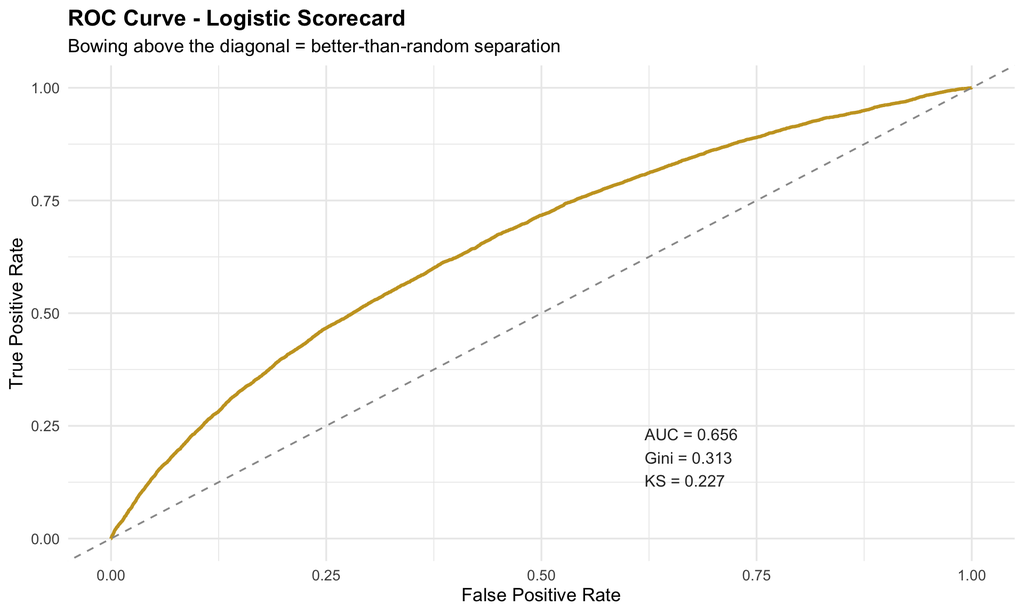

```r
pred_obj <- prediction(test_pred$pred_lr, test_pred$target)
perf <- performance(pred_obj, "tpr", "fpr")

roc_df <- tibble(
  fpr = perf@x.values[[1]],
  tpr = perf@y.values[[1]]
)

auc_val  <- compute_auc(test_pred$target, test_pred$pred_lr)
gini_val <- compute_gini(test_pred$target, test_pred$pred_lr)
ks_val   <- compute_ks(test_pred$target, test_pred$pred_lr)

ggplot(roc_df, aes(fpr, tpr)) +
  geom_line(colour = "#C9A227", linewidth = 1.1) +
  geom_abline(linetype = "dashed", colour = "#999999") +
  annotate("text", x = 0.62, y = 0.18,
           label = sprintf("AUC = %.3f\nGini = %.3f\nKS = %.3f",
                           auc_val, gini_val, ks_val),
           hjust = 0, size = 4, colour = "#2E2E2E") +
  labs(title = "ROC Curve - Logistic Scorecard",
       subtitle = "Bowing above the diagonal = better-than-random separation",
       x = "False Positive Rate", y = "True Positive Rate") +
  theme_minimal(base_size = 13) +
  theme(plot.title = element_text(face = "bold"))
```

```r
cat("Discrimination summary\n")
```

```
## Discrimination summary
```

```r
cat("  AUC: ", round(auc_val, 4), "\n")
```

```
##   AUC:  0.6563
```

```r
cat("  Gini:", round(gini_val, 4), "\n")
```

```
##   Gini: 0.3126
```

```r
cat("  KS:  ", round(ks_val, 4), "\n")
```

```
##   KS:   0.2272
```

# Section 2: Calibration

Discrimination tells us the model *ranks* risk correctly. Calibration asks something different: when the model says “7% chance of default,” do 7% of those applicants actually default? A scorecard’s points scale is anchored on odds, so calibration is essential - a miscalibrated model produces misleading scores even if it ranks well.

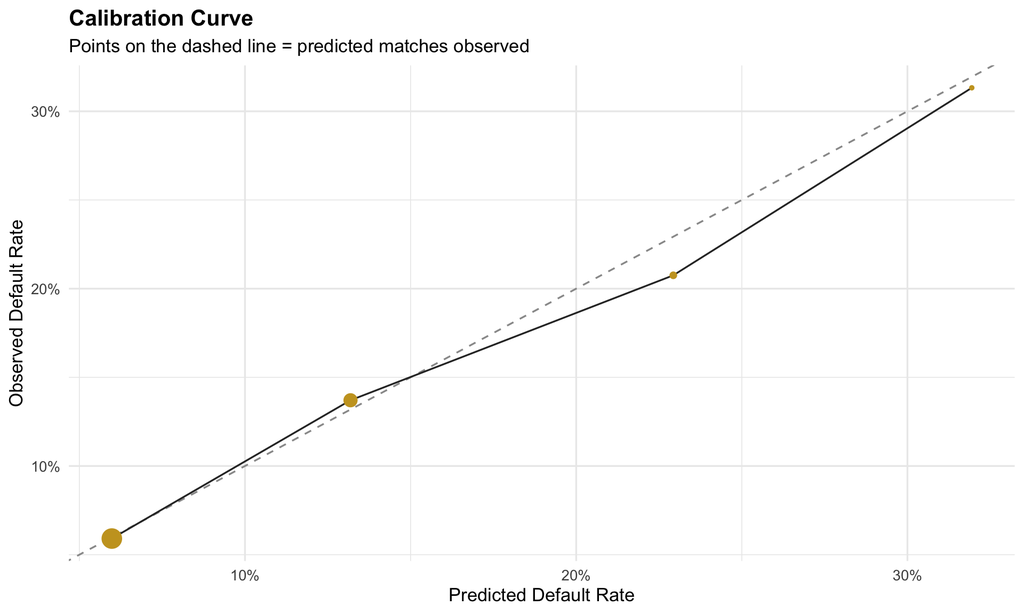

```r
calib <- compute_calibration(test_pred$target, test_pred$pred_lr, n_bins = 10) %>%
  filter(!is.na(expected_rate))

ggplot(calib, aes(expected_rate, observed_rate)) +
  geom_abline(linetype = "dashed", colour = "#999999") +
  geom_line(colour = "#2E2E2E") +
  geom_point(aes(size = n), colour = "#C9A227") +
  scale_x_continuous(labels = percent_format()) +
  scale_y_continuous(labels = percent_format()) +
  scale_size_continuous(guide = "none") +
  labs(title = "Calibration Curve",
       subtitle = "Points on the dashed line = predicted matches observed",
       x = "Predicted Default Rate", y = "Observed Default Rate") +
  theme_minimal(base_size = 13) +
  theme(plot.title = element_text(face = "bold"))
```

```r
calib_mse <- mean((calib$expected_rate - calib$observed_rate)^2, na.rm = TRUE)
cat("Calibration MSE:", round(calib_mse, 6), "\n")
```

```
## Calibration MSE: 0.000135
```

```r
cat("(Lower is better; < 0.002 is excellent)\n")
```

```
## (Lower is better; < 0.002 is excellent)
```

```r
if (calib_mse < 0.002) {
  cat("Model is well-calibrated - predicted probabilities are trustworthy.\n")
} else {
  cat("Calibration drift - consider a recalibration step (e.g. isotonic/Platt).\n")
}
```

```
## Model is well-calibrated - predicted probabilities are trustworthy.
```

# Section 3: Stability - Population Stability Index (PSI)

PSI measures whether a score distribution has shifted between two populations. In production it compares the development sample against incoming applicants; here, with no future data yet, we compare **train vs. test** as a sanity check that the score is stable across samples drawn from the same population.

Rule of thumb: PSI < 0.10 = stable, 0.10–0.25 = minor shift (monitor), > 0.25 = significant shift (investigate).

```r
# Score both train and test through the model, then compare the predicted
# probability distributions. Bins are fixed on the train (reference) set.
train_paths <- c("data/processed/train_woe.rds", "../data/processed/train_woe.rds")
train <- readRDS(train_paths[file.exists(train_paths)][1])
train_prob <- predict(model_lr, newdata = train, type = "response")

psi <- function(expected, actual, n_bins = 10) {
  cuts <- quantile(expected, probs = seq(0, 1, length.out = n_bins + 1),
                   na.rm = TRUE, type = 7)
  cuts[1] <- -Inf; cuts[length(cuts)] <- Inf
  e <- cut(expected, breaks = unique(cuts))
  a <- cut(actual,   breaks = unique(cuts))
  e_pct <- as.numeric(table(e)) / length(expected)
  a_pct <- as.numeric(table(a)) / length(actual)
  e_pct[e_pct == 0] <- 1e-6
  a_pct[a_pct == 0] <- 1e-6
  sum((a_pct - e_pct) * log(a_pct / e_pct))
}

psi_val <- psi(train_prob, test_pred$pred_lr, n_bins = 10)

cat("Train vs. Test PSI (on predicted probability):", signif(psi_val, 4), "\n\n")
```

```
## Train vs. Test PSI (on predicted probability): 4.779e-05
```

```r
if (psi_val < 0.10) {
  cat("Stable (PSI < 0.10) - score distribution holds across samples.\n")
} else if (psi_val < 0.25) {
  cat("Minor shift (0.10-0.25) - monitor in production.\n")
} else {
  cat("Significant shift (> 0.25) - investigate population drift.\n")
}
```

```
## Stable (PSI < 0.10) - score distribution holds across samples.
```

```r
cat("\nThe PSI here is near zero by design: train and test are random draws\n")
```

```
##
## The PSI here is near zero by design: train and test are random draws
```

```r
cat("from one population, so their score distributions are nearly identical.\n")
```

```
## from one population, so their score distributions are nearly identical.
```

```r
cat("In production this same PSI is computed monthly (development sample vs.\n")
```

```
## In production this same PSI is computed monthly (development sample vs.
```

```r
cat("incoming applicants) to detect population drift and trigger model refreshes.\n")
```

```
## incoming applicants) to detect population drift and trigger model refreshes.
```

# Section 4: Fairness Slice

A lending model must not produce systematically different outcomes across protected groups without justification. We check whether the model’s predicted risk and approval behaviour differ by **gender** and **age band**, using the raw demographic fields from `application_train`.

This is a screening check, not a full fairness audit - but it surfaces obvious disparate impact, which a credit model cannot ship with.

```r
# Resolve the raw application file whether knitting from root or notebooks/
app_paths <- c("data/raw/application_train.csv", "../data/raw/application_train.csv")
app_path <- app_paths[file.exists(app_paths)][1]

if (!is.na(app_path)) {
  demo <- read_csv(app_path, show_col_types = FALSE) %>%
    transmute(
      SK_ID_CURR,
      gender = CODE_GENDER,
      age_band = cut(-DAYS_BIRTH / 365.25,
                     breaks = c(-Inf, 30, 40, 50, 60, Inf),
                     labels = c("<30", "30-40", "40-50", "50-60", "60+"))
    )

  # test_scored carries SK_ID_CURR, so we join demographics directly on ID
  fair <- test_scored %>%
    select(SK_ID_CURR, target, pred = pred_lr, score) %>%
    left_join(demo, by = "SK_ID_CURR") %>%
    filter(gender %in% c("M", "F"))

  cat("By Gender\n")
  fair %>%
    group_by(gender) %>%
    summarise(n = n(),
              actual_default = percent(mean(target), 0.01),
              mean_pred = percent(mean(pred), 0.01),
              mean_score = round(mean(score)),
              .groups = "drop") %>% print()

  cat("\nBy Age Band\n")
  fair %>% filter(!is.na(age_band)) %>%
    group_by(age_band) %>%
    summarise(n = n(),
              actual_default = percent(mean(target), 0.01),
              mean_pred = percent(mean(pred), 0.01),
              mean_score = round(mean(score)),
              .groups = "drop") %>% print()

  # Disparate-impact style read: spread in mean predicted risk across groups
  g_spread <- fair %>% group_by(gender) %>%
    summarise(m = mean(pred), .groups = "drop")
  spread <- max(g_spread$m) - min(g_spread$m)
  cat("\nGender spread in mean predicted risk:", percent(spread, 0.01), "\n")
  if (spread < 0.03) {
    cat("No large gender disparity in predicted risk (< 3pp). The model's\n")
    cat("predictions track each group's actual default rate, so it reflects\n")
    cat("observed base rates rather than adding disparity.\n")
  } else {
    cat("Gender gap in predicted risk - note this may reflect true base-rate\n")
    cat("differences; a full audit would test whether the model adds disparity\n")
    cat("beyond the observed base rates.\n")
  }

} else {
  cat("application_train.csv not found - fairness slice skipped.\n")
  cat("If it shows a cloud icon in Finder, download it locally and re-knit.\n")
}
```

[output not shown]

# Section 5: Validation Verdict

```r
cat("VALIDATION SUMMARY\n")
```

```
## VALIDATION SUMMARY
```

```r
cat("Discrimination : Gini", round(gini_val, 3),
    "| KS", round(ks_val, 3), "| AUC", round(auc_val, 3), "\n")
```

```
## Discrimination : Gini 0.313 | KS 0.227 | AUC 0.656
```

```r
cat("Calibration    : MSE", round(calib_mse, 6),
    if (calib_mse < 0.002) "(excellent)\n" else "(review)\n")
```

```
## Calibration    : MSE 0.000135 (excellent)
```

```r
cat("Stability      : PSI", round(psi_val, 3),
    if (psi_val < 0.10) "(stable)\n" else "(monitor)\n")
```

```
## Stability      : PSI 0 (stable)
```

```r
cat("Fairness       : screened by gender and age band (see Section 4)\n\n")
```

```
## Fairness       : screened by gender and age band (see Section 4)
```

```r
cat("Verdict: the model discriminates modestly but honestly, is well-\n")
```

```
## Verdict: the model discriminates modestly but honestly, is well-
```

```r
cat("calibrated, stable across samples, and shows no obvious disparate\n")
```

```
## calibrated, stable across samples, and shows no obvious disparate
```

```r
cat("impact. It is suitable for deployment as a scorecard with the\n")
```

```
## impact. It is suitable for deployment as a scorecard with the
```

```r
cat("decision policy defined in the scorecard notebook.\n")
```

```
## decision policy defined in the scorecard notebook.
```

**Generated:** 2026-06-29  
**Notebook:** Model Validation  
**Status:** Complete

> Sensitive-topic note: fairness analysis here is a screening check, not a certified audit. A production deployment would pair this with a formal disparate-impact review and ongoing monitoring.